# Shiny App Help

27 de marzo de 2019

## App Description & Interface

The application predicts the Weight of a chick based on the chosen values for:

- Chick Diet
- Chick Age

Baseline data is the ChickWeight dataset that comes with R. The App is divided on two main panels:

- Left panel: Input controls to set values of predictor variables / features. Checkbox allows to choose to display reference lines in the chart on the right panel.
- Right panel: Scatter plot of points in data set plus the new predicted value according to the values selected for predictor variables. Numeric estimated value resulting from a linear model is also displayed below the chart.

## Left-hand panel: Help

Use this panel to provide inputs to the App:

- Chick Diet: select a value between 1 and 4
- Chick Age: use the slider to choose a value between 0 and 25 days.
- Enable or Disable the checkbox to show or remove the regression line plus a horizontal and a vertical line for the pair predicted value, chosen chick age value.

## Right-hand panel: Help (1/2)

This is the main panel to display the output.

The app shows a chart like the one below but limited to the points with the Chick Diet specified in the left-hand panel.

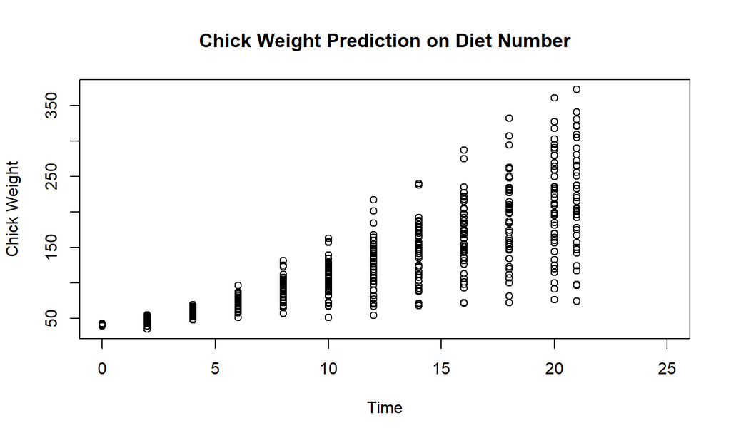

## Right-hand panel: Help (2/2)

The plot in the App also shows a red dot that is the predicted value for the Chick Weight chosen on the slider on the left-hand panel.

Below the chart, the numeric value for the predicted Chick Weight, considering the values chosen for Chick Diet and Chick Age.